# Geography 176A

Flood Risk in Mission Creek: Past, Present, Future

Lab 06

# Background

Mission Creek runs from Rattle Snake Canyon, through Santa Barbara, and drains into the water front near Stearns Wharf. It has a USGS gaging location situated ~$\frac{1}{3}$ up the mainstem.

In the past two decades this basin has flooded on numerous occasions causing damage along State Street and the surrounding neighborhoods.

Below is a map sharing a collection of videos and images from the 1995, 1998 and 2017 flood events.

[interactive chart not shown]

In this lab you will build a partial or full (depending if you attempt the Extra Credit) Flood Inundation Map (FIM) Library for the Mission Creek Basin. More importantly, this lab is the summation of [geography 176A](https://mikejohnson51.github.io/spds/) and will focus of four key tasks:

1. Finding and bringing data into R using Web APIs
2. Aligning retrieved object and field data
3. Preparing terrain data for analysis
4. Carrying out a simple, multi-data structure (raster/vector) analysis.

The skills we have been indirectly practicing all quarter including project structure and file path management will be critical here.

## Libraries

Attach your needed libraries:

```r
library(sf)        # vector manipulation
library(raster)    # raster manipulation
library(fasterize) # "faster" raster
library(whitebox)  # terrain analysis

# Data libraries
library(osmdata)   # OSM API
library(elevatr)   # Elevation  Web Tiles
```

## Flooding Jargon

- **stage** = height of the water in a channel
- **streamflow** = the rate of water flowing in a channel
- **basin** = an area in which all cells contribute to a common outlet (an area or ridge of land that separates waters flowing to different rivers, basins, or seas)
- **flowpath** = the linear path over which water flows (river)
- **HAND** = Height Above Nearest Drainage, “*how high is a cell above its nearest river cell?*”

# Collecting Data

Your job is to estimate the number of buildings impacted in the 2017 Mission Creek flood event using the Height Above Nearest Drainage Flood mapping methodology which is currently being explored by NOAA as an operational flood mapping technique for CONUS.

Recently research into this technique has accelerated ([1](https://nhess.copernicus.org/articles/19/2405/2019/), [2](https://onlinelibrary.wiley.com/doi/full/10.1111/1752-1688.12660), [3](https://agupubs.onlinelibrary.wiley.com/doi/full/10.1029/2019WR024837)) and been awarded several multi-million dollar grants to advance ([1](https://ladailypost.com/noaa-awards-grants-to-small-businesses-developing-technology/), [2](https://ufokn.github.io/UFOKN/)). These projects focus on enhancing HAND forecasts with satellite imagery (particularly Sentinel 2) and on extending flood forecasts to impact assessments by interrelating feature (like OSM) and raster products.

The first part of the lab is collecting the data needed for the analysis. This includes representations of the elevation grid, the river network, and building structures.

### Basin boundary

HAND is a watershed focused analysis, therefore we need the boundaries of a local basin to define our AOI.

Use the [Network Linked Data Index (NLDI](https://waterdata.usgs.gov/blog/nldi-intro/) to identify the basin associated with the USGS gage: `USGS-11119750`.

Remember that basin boundaries can be accessed from the NLDI using the following URL pattern:

`https://labs.waterdata.usgs.gov/api/nldi/linked-data/nwissite/USGS-**SITEIDHERE**/basin`

Where you fill in the **SITEIDHERE** with the appropriate gage ID.

The geojson stored at that URL can then be read directly into R (as a simple feature object) using `read_sf()`.

Go ahead and load the basin into your working session.

### Elevation Data

Once you have the basin boundary, get elevation data using `elevatr` and a zoom level of 13. Once returned,

- **crop/mask** the elevation data to the basin boundary and convert elevation values from meters to feet (1m = 3.281 feet)
- **Write** the raster to your `data` folder as a `tif` file (use `writeRaster`)

### Buildings and river-network data

Within the basin we want to find the exposed buildings, **and** the river flowpaths that carry water.

Use OSM to query building and stream data

- For buildings, identify the `POLYGON` (building footprint) **centroids** and *clip* them to the basin boundary
  - Additionally, extract the railway `POINT` from the buildings for latter plotting
- For the **streams**, keep all `LINESTRING` elements and *clip* them to the basin boundary

# Terrain Analysis

For your HAND flood analysis, you will need 2 new terrain based datasets:

- a “Hillshade” raster for visualization
- a “Height Above Nearest Drainage” (HAND) raster for rapid flood assessment.

Each of these will be created using the [`whitebox`](https://giswqs.github.io/whiteboxR/) frontend toolkit and will be based on the elevation raster you saved above.

### Hillshade

Starting with the filepath to your elevation tif, create a hillshade raster in your data folder using `wbt_hillshade`. At minimum, `wbt_hillshade` requires two arguments, the path to the raw data (elevation tif), and an output path to where the new data should be saved. Feel free to leave the other defaults of `wbt_hillshade` unchanged.

Once processed, read your hillshade tif file into R and plot it using the color palette `gray.colors(256, alpha = .5)` (also, remove the legend)

On top of the hillshade, plot the basin boundary **and** the river flowlines.

### Height Above Nearest Drainage

Height Above Nearest Drainage is a hydrologically normalized DEM in which each cell represents the height above the nearest cell designated as a river. Therefore, to create a HAND product we need a representation of the DEM, and the river network on the same raster grid.

If we think of the basin as a bathtub, then the height of the water in the channel will spread evenly across the landscape submerging any cell with a HAND value less then the height of the water in the channel. That is, if the height of the water (stage) in a river is 4 feet, any cell with a HAND value less then 4 will be flooded. This idea is illustrated below:

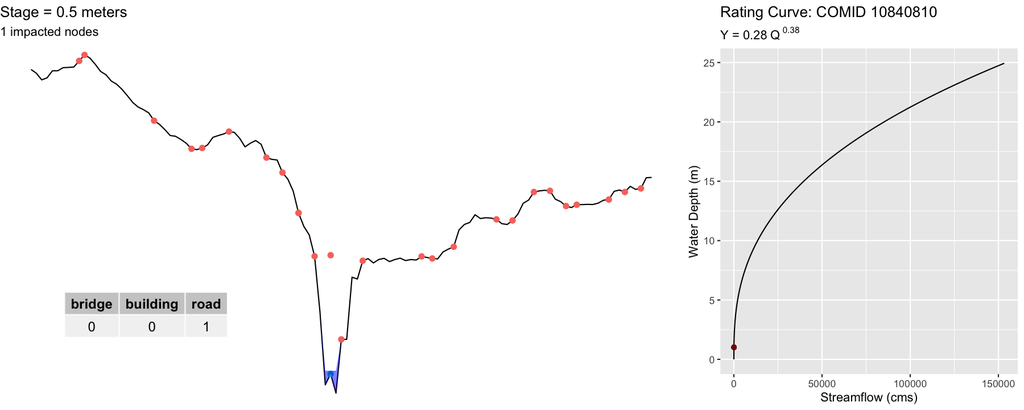

To compute a HAND raster, two intermediate steps are needed: (1) a raster representing the river network and (2) a hydrologically corrected DEM (pit filled).

#### Creating the river raster

First, we want to rasterize our flowlines to the grid of our elevation raster. Remember that fasterize works only with `POLYGON` or `MULTIPOLYGON` objects. Currently our river network is a `LINESTRING.`

- To add an area to our flowlines, buffer them using a distance of 10 meters. Think carefully about the process you need to do this with respect to CRS.
- Once buffered, use `fasterize::fasterize` to create your river network raster using the elevation grid as the template
- Write the river raster to your `data` folder.

#### Creating the hydrologically corrected surface

We will use the whitebox tool `wbt_breach_depressions` to correct errors in our DEM/elevation grid. This utility runs Lindsay’s (2016) algorithm to breach (fill) all of the depressions in a DEM.

This utility requires two arguments, (1) the local path to the elevation grid, and (2) a path to write the output raster.

Execute this utility to create a conditioned elevation product.

#### Creating the HAND raster

`wbt_elevation_above_stream` can be used to generate a HAND raster. It requires three arguments: (1) the path to the conditioned DEM, (2) the path to the rasterized river networks, and (3) a output location to write the final file.

Execute this utility to create a final HAND raster.

### Correcting to local reference datum

Great we now have a HAND raster that uses the river network as a local reference datum. The problem is that our recorded stage values, are not referenced to that local datum. Instead, the USGS records stage as the height above a local control point and **not** to the bottom of the river.

This is illustrated by the fact that instances of 0 measured flow, correspond to a recorded gage height of 3.69 feet (see below)

[figure not shown]

To correct for this we need to **add** the 3.69 foot offset to our current HAND raster and then ensure our river network still has a HAND value of 0. To do this:

- Read in the HAND data from the file output from `wbt_elevation_above_stream`
- Read in the river raster data
- **Add** the offset to the entire HAND raster
- Then, ensure that if the cell has a value of 1 in the river raster then its HAND value is set to 0.
- Save the new, offset raster to your `data` folder

# 2017 Impact Assessment

### Map the flood

The gage upstream of `USGS-11119750` (`USGS-11119745`) has a better, longer, gage record.

Since we are making the simplified assumption that the height of water in the basin is constant at any point in time we can look at this gage.

[figure not shown]

The historical peak chart shows that on February 17<sup>th</sup> 2017, the river reached a stage of 10.02 feet - the largest in the observed record.

This means that every cell in the HAND raster with a HAND value less than or equal to 10.02 is flooded. Knowing this:

- Read in the corrected HAND raster
- Create a flood map where any cell with a HAND value greater then 10.02 is set to `NA`.
- Plot your hillshade as you did above
- Overlay the flood map using the `rev(blues9)` color palette and `add = TRUE`
- Plot the railway station as a point of reference colored in `green`, with `cex = 1`, and `pch = 16`

> Does that map look accurate?

### Estimate the impacts

With a defined map, we want to determine the number of buildings impacted by this event.

- Use the OSM building centroids to `extract` the flood depth at each structure from your flood raster.
- Count the number **not** equal to `NA` in order to determine the number of impacted structures.

Then, starting with overlaid hillshade/flood map:

- Add the buildings centroids to the map:
  - impacted buildings should be colored `red`,
  - non-impacted buildings should be colored `black`.
  - All should be plotted with `pch = 16` and `cex = .08`.
- Add the railroad as a reference point, colored in `grean`, with `cex = 1` and `pch = 16`
- In the title (main = “…”) detail the number of impacted structures and stage level programatically using `paste`

# Flood Inudation Map library

> This part is extra credit

[Flood Inundation Map libraries](https://www.usgs.gov/mission-areas/water-resources/science/flood-inundation-map-fim-libraries?qt-science_center_objects=0#qt-science_center_objects) help communities apply real-time stream data and National Weather Service flood forecasts to form a two-dimensional flood warning system. These 2D warning systems help estimate the extent of a flood and identify at-risk areas and resources in advance of floodwaters arriving.

You have been asked to create a FIM library for Mission Creek for stage values ranging from 0 to 20 feet. You have also been asked to animate this library as a GIF file showing the hillshade, flood level, and impacted buildings for each stage.

Last, the city is interested in zooming in on the lower portion of the basin contained within the “Santa Barbara” bounding box (defined in OSM). You can get this boundary using the `AOI` package:

```r
(sb = AOI::aoi_get("Santa Barbara"))
```

```
## Simple feature collection with 1 feature and 1 field
## geometry type:  POLYGON
## dimension:      XY
## bbox:           xmin: -119.8598 ymin: 34.33603 xmax: -119.6399 ymax: 34.46392
## geographic CRS: WGS 84
##                         geometry       request
## 1 POLYGON ((-119.8598 34.3360... Santa Barbara
```

Once you have your AOI:

- `crop/clip` the basin, HAND raster, and Hillshade raster to the AOI extent
- Generate/animate to your FIM library by placing the plot from above within the `gifski` function (see below)

```r
gifski::save_gif({
  for(i in 0:20) {
    ...
  }
}, gif_file = "data/mission-creek-fim.gif",
   width = 600, height = 600,
   delay = .7, loop = TRUE)
```

This function skeleton loops over the stage values 0 to 20

- Fill in the ‘…’ with your plotting code making sure it reacts to the incoming stage value `i`
- For each stage i
  - Generate a new flood map
  - Identify the impacted buildings
  - Map the hillshade, floodmap, buildings, train station, and basin boundary following the same guidlines as above
  - The plot title should also update describing the number of impacted buildings and the stage being shown
- Make sure your gif code is not run when knit by setting the r chunk to `eval = FALSE`
- Run the code yourself to generate `data/mission-creek-fim.gif`
- Place `data/mission-creek-fim.gif` in the knit document as an image

Your final product should look like this:

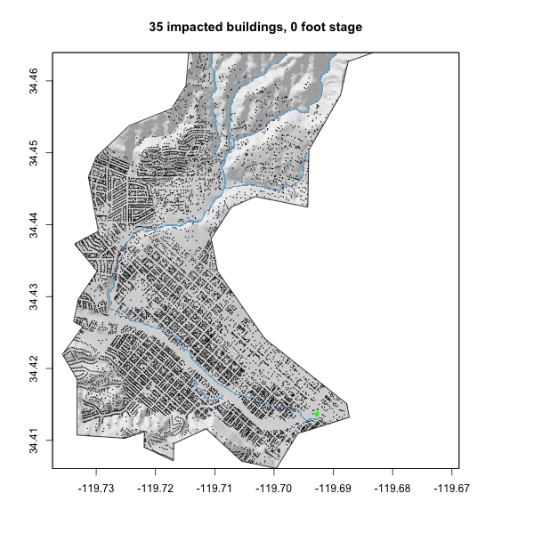

> Why at 0 stage, are we capturing impacted buildings?

Congrats on a great, difficult quarter. You guys were able to do a tremendous amount over the course of six weeks. The highlights of your labs include:

- Building your own personal webpage
- Performing a partial COVID analysis similar to the [California Department of Public Health](https://covid19.ca.gov/safer-economy/)
- Analyzing the impacted populations at the border zone, numbers that [drive policy and current events](https://www.justsecurity.org/65136/congress-tackles-the-100-mile-border-zone-for-federal-checkpoints/)
- Completing a major, full scale dam analysis [similar to ongoing efforts](https://www.ussdams.org/our-news/americas-aging-dams-in-need-of-repair/) to monitor dam patterns and health in the USA.
- Implementing a remote senseing based [flood analysis](https://earthobservatory.nasa.gov/images/88832/unseasonal-flooding-in-iowa) similar to those carried out by the NASA Earth Observatory
- Constructing a complete (or partial) FIM library in the same way NOAA is trying to generalize the USA using the combined National Water Model - HAND method, and companies like Azavia, NSF, and [ESRI](https://www.esri.com/content/dam/esrisites/en-us/about/events/media/2019-nspss-pdf/NSPSS_36.pdf) are try to operationalize

While many of these were water resource focused, the core of them is the combination of data science, vector, and raster data structures and the analysis these representations of space and measurement can offer.

They concepts can be extended to any question of feild where data has location information.

# Rubric

- **Question 1: Data Ingest** (10)
- **Question 2: Terrain Analysis** (15)
- **Question 3: 2017 Impact Assessment** (15)
- **Extra Credit: FIM Library** (20)
- **Well Structured and appealing Rmd deployed as web page** (10)

**Total:** 50 points (70 total points)

# Submission

You will submit a URL to your web page deployed with GitHub pages.

To do this:

- Knit your lab 6 document
- Stage/commit/push your files
- If you followed the naming conventions in the “Set Up” of lab 2, your lab 6 link will be available at:

`https://USERNAME.github.io/geog-176A-labs/lab-06.html`

Submit this URL in the appropriate Gauchospace dropbox.